## Ex-02.1-pefr

Paul Johnson, CRMDA <pauljohn@ku.edu>

Feb. 8 2018

Abstract

# Data import

```r
if (!file.exists("pefr.dta12")){
    download.file("http://www.stata-press.com/data/mlmus3/pefr.dta",
                  destfile = "pefr.dta12")
}
library(foreign)
pefr <- read.dta("pefr.dta12")
```

```r
rockchalk::summarize(pefr)
```

```
## Numeric variables
##              id       wp1      wp2      wm1      wm2
## min          1      178      165      259      227
## med          9      434      429      445      444
## max         17      656      638      658      642
## mean         9      450.35   445.41   452.47   455.35
## sd           5.05   116.31   119.61   113.12   111.32
## skewness     0       -0.31    -0.31     0.05    -0.18
## kurtosis    -1.41     0.27     0.01    -0.78    -0.47
## nobs        17       17       17       17       17
## nmissing     0        0        0        0        0
```

```r
pefr$id.orig <- pefr$id
pefr$id <- as.factor(pefr$id)
```

## Visualize the imported data

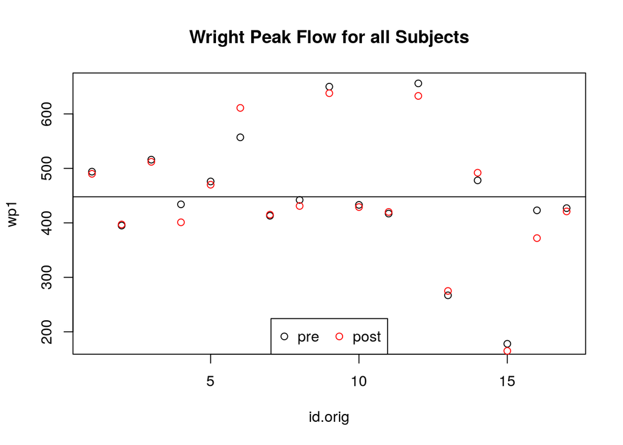

```r
plot(wp1 ~ id.orig, data = pefr, main = "Wright Peak Flow for all Subjects")
points(wp2 ~ id, data = pefr, col = "red")
abline(h = (mean(pefr$wp1) + mean(pefr$wp2)) / 2)
legend("bottom", legend = c("pre", "post"), col = c("black", "red"),
       pch = c(1,1), horiz = TRUE)
```

# 2.1.1a: Reshape

Intention is to create “stacked” versions of “wm” and “wp” variables. Try R’s built-in reshape, this is an easy case, a good one to explore the reshape function.

```r
head(pefr)
```

```
##   id wp1 wp2 wm1 wm2 id.orig
## 1  1 494 490 512 525       1
## 2  2 395 397 430 415       2
## 3  3 516 512 520 508       3
## 4  4 434 401 428 444       4
## 5  5 476 470 500 500       5
## 6  6 557 611 600 625       6
```

```r
pefrlong <- reshape(pefr, direction="long",
                    varying = list(c("wp1", "wp2"), c("wm1", "wm2")),
                    v.names = c("wp", "wm"),
                    timevar = "occasion")
head(pefrlong, 10)
```

```
##      id id.orig occasion  wp  wm
## 1.1   1       1        1 494 512
## 2.1   2       2        1 395 430
## 3.1   3       3        1 516 520
## 4.1   4       4        1 434 428
## 5.1   5       5        1 476 500
## 6.1   6       6        1 557 600
## 7.1   7       7        1 413 364
## 8.1   8       8        1 442 380
## 9.1   9       9        1 650 658
## 10.1 10      10        1 433 445
```

# 2.1.1b: mixed model with ML

Set `REML = FALSE` because we want maximum likelihood estimates of the variance component.

```r
library(lme4)
m1 <- lmer(wp ~ (1|id), data = pefrlong, REML = FALSE)
summary(m1)
```

```
## Linear mixed model fit by maximum likelihood  ['lmerMod']
## Formula: wp ~ (1 | id)
##    Data: pefrlong
##
##      AIC      BIC   logLik deviance df.resid
##    368.1    372.6   -181.0    362.1       31
##
## Scaled residuals:
##      Min       1Q   Median       3Q      Max
## -1.69563 -0.25983 -0.02527  0.20358  1.84414
##
## Random effects:
##  Groups   Name        Variance Std.Dev.
##  id       (Intercept) 12871.0  113.45
##  Residual               234.3   15.31
## Number of obs: 34, groups:  id, 17
##
## Fixed effects:
##             Estimate Std. Error t value
## (Intercept)   447.88      27.64    16.2
```

```r
confint(m1)
```

```
## Computing profile confidence intervals ...
```

```
##                 2.5 %    97.5 %
## .sig01       83.52801 166.03232
## .sigma       11.31304  22.34698
## (Intercept) 390.49780 505.26691
```

# 2.1.2 Compare estimates for the wm and wp variables

First I’ll fit the same mixed model with the `wm` outcome variable. We need this for comparison.

```r
m2 <- lmer(wm ~ (1|id), data = pefrlong, REML = FALSE)
summary(m2)
```

```
## Linear mixed model fit by maximum likelihood  ['lmerMod']
## Formula: wm ~ (1 | id)
##    Data: pefrlong
##
##      AIC      BIC   logLik deviance df.resid
##    375.2    379.7   -184.6    369.2       31
##
## Scaled residuals:
##      Min       1Q   Median       3Q      Max
## -2.44654 -0.33601  0.03936  0.35196  2.37495
##
## Random effects:
##  Groups   Name        Variance Std.Dev.
##  id       (Intercept) 11458.9  107.05
##  Residual               396.4   19.91
## Number of obs: 34, groups:  id, 17
##
## Fixed effects:
##             Estimate Std. Error t value
## (Intercept)   453.91      26.19   17.33
```

Lets compare the models side-by-side:

```r
library(rockchalk)
or <- outreg(list("Wright Peak flow" = m1, "Mini Wright meter" = m2))
```

```r
or <- gsub("[ ]{2,}", " ", or)
cat(or)
```

[output not shown]

I did not understand this question in the RHS book, but the answer in the teacher’s manual points our attention to the estimate of the variance of the residual in the fitted models. They observe that the residual error in the Wright peak-flow model (the one using `wp`) is 15.3, while the residual standard error in the other is 19.9.

The “reliability” of the measurement is the similarity of results when applied to an equivalent case. Here, we assume that the medical condition of the patients did not change between occasion 1 and occasion 2, so the observed fluctuation in their score is due, by definition, to measurement error.

# 2.1.3: estimates for predictions of random effects

## Retrieve predictions of the random effects from m1

In the usual GLS interpretation of the mixed model, these are the empirical bayes est. of random intercept (RHS, p. 109-113). They were often called “blups”, but now it is recommended we refer to them as posterior modes.

```r
m1.ranef <- ranef(m1, condVar = TRUE)
m1.ranef
```

```
## $id
##    (Intercept)
## 1     43.71973
## 2    -51.41440
## 3     65.52130
## 4    -30.10832
## 5     24.89110
## 6    134.88993
## 7    -33.57675
## 8    -11.27969
## 9    194.34876
## 10   -16.73008
## 11   -29.11734
## 12   194.84425
## 13  -175.28696
## 14    36.78286
## 15  -273.88952
## 16   -49.92793
## 17   -23.66695
##
## with conditional variances for "id"
```

That demonstrates the predicted values of the “group-level” intercepts, but here a “group” is one patient, observed twice.

There is a very handy way to visualize these random effects built into lme4. The following is a “dotplot” showing the random effects for each `id`. This includes “error bars”, which use information we will describe next.

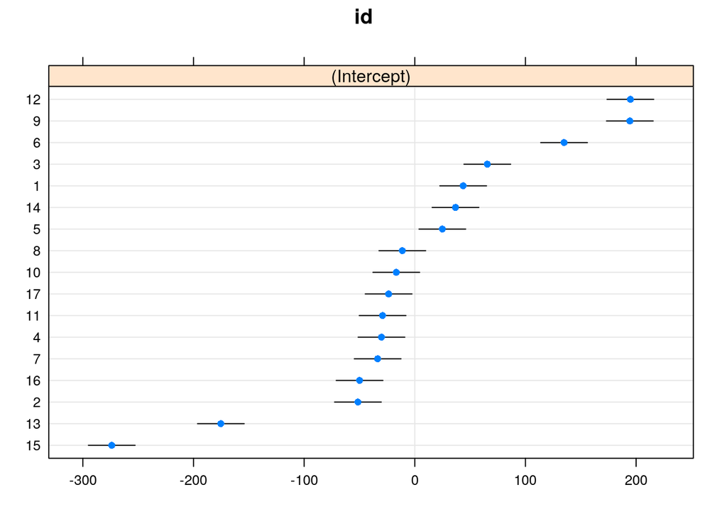

```r
library(lattice)
dotplot(m1.ranef)
```

The dotplot includes error bars to indicate uncertainty, a 95% confidence interval if you care to call it that. It is created by a simple calculation, $ranef +/- 1.96\cdot std.err$. Where do the standard errors come from?

The information about uncertainty associated with each posterior mode is tucked away inside the object `m1.ranef`. Here’s how I know: I ask for the attributes of the object:

```r
attributes(m1.ranef[["id"]])
```

```
## $names
## [1] "(Intercept)"
##
## $row.names
##  [1] "1"  "2"  "3"  "4"  "5"  "6"  "7"  "8"  "9"  "10" "11" "12" "13" "14"
## [15] "15" "16" "17"
##
## $class
## [1] "data.frame"
##
## $postVar
## , , 1
##
##          [,1]
## [1,] 116.0905
##
## , , 2
##
##          [,1]
## [1,] 116.0905
##
## , , 3
##
##          [,1]
## [1,] 116.0905
##
## , , 4
##
##          [,1]
## [1,] 116.0905
##
## , , 5
##
##          [,1]
## [1,] 116.0905
##
## , , 6
##
##          [,1]
## [1,] 116.0905
```

[output cut: 40 more lines]

```
##
## , , 15
##
##          [,1]
## [1,] 116.0905
##
## , , 16
##
##          [,1]
## [1,] 116.0905
##
## , , 17
##
##          [,1]
## [1,] 116.0905
```

If I want to create standard errors, I must extract those variance values, and convert them to standard errors by taking the square root of each one. Here one way. (See RHS, comparative standard error, p. 113-114).

```r
m1.ranef.se <- sqrt( attr(m1.ranef[["id"]], "postVar")[1,1, ])
## Not easy. Get the 3-d array from attr(m1.ranef[["id"]], "postVar")
## Then snip off the part we need with [1, 1, ]
## Then take square root
```

## 2.1.3 Compare those random effects with the Mini Wright values

```r
m2 <- lmer(wm ~ (1|id), data = pefrlong, REML = FALSE)
summary(m2)
```

```
## Linear mixed model fit by maximum likelihood  ['lmerMod']
## Formula: wm ~ (1 | id)
##    Data: pefrlong
##
##      AIC      BIC   logLik deviance df.resid
##    375.2    379.7   -184.6    369.2       31
##
## Scaled residuals:
##      Min       1Q   Median       3Q      Max
## -2.44654 -0.33601  0.03936  0.35196  2.37495
##
## Random effects:
##  Groups   Name        Variance Std.Dev.
##  id       (Intercept) 11458.9  107.05
##  Residual               396.4   19.91
## Number of obs: 34, groups:  id, 17
##
## Fixed effects:
##             Estimate Std. Error t value
## (Intercept)   453.91      26.19   17.33
```

```r
m2.ranef <- ranef(m2, condVar = TRUE)
m2.ranef.se <- sqrt(attr(m2.ranef[["id"]], "postVar")[1,1, ])
```

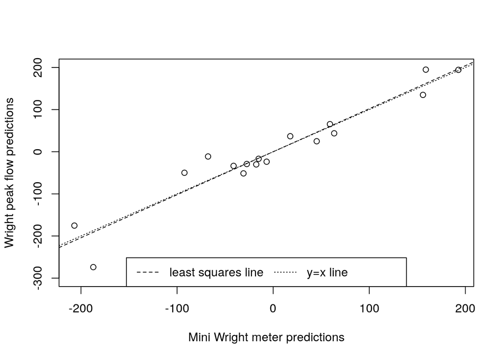

```r
## Not too easy to get the random effects as vectors, by themselves
y <- m1.ranef[["id"]]$`(Intercept)`
x <- m2.ranef[["id"]]$`(Intercept)`
plot(y ~ x,
     ylim = c(-300, 200), xlab = "Mini Wright meter predictions",
     ylab = "Wright peak flow predictions")
myx <- lm(y ~ x)
abline(myx, lty = 2)
abline(a = 0, b = 1, lty = 3)
legend("bottom", legend = c("least squares line", "y=x line"),
       lty = c(2, 3), horiz=TRUE)
```

# 2.1.4 Compare standard errors

The wm method:

```r
m2.ranef.se
```

```
##  [1] 13.95887 13.95887 13.95887 13.95887 13.95887 13.95887 13.95887
##  [8] 13.95887 13.95887 13.95887 13.95887 13.95887 13.95887 13.95887
## [15] 13.95887 13.95887 13.95887
```

```r
m1.ranef.se
```

```
##  [1] 10.77453 10.77453 10.77453 10.77453 10.77453 10.77453 10.77453
##  [8] 10.77453 10.77453 10.77453 10.77453 10.77453 10.77453 10.77453
## [15] 10.77453 10.77453 10.77453
```

Wait. Why are all of those the same number? This does not usually happen when there are predictors which differentiate the cases and there are different numbers of observations for each group. Here, we have exactly 2 observations for each group (person), and the only predictor is the `id` and thus the uncertainty for each random effect is the same.